# Machine Learning: Apprentissage Supervisé

- Louis CHOPINET
- Valentin ANOT

## Librairies externes

- numpy : Génération de nombres aléatoires et lecture/écriture de fichiers .npy
- matplotlib : Génération de graphes
- scikit-learn : Clustering et Heuristiques
- pandas : organisation et sauvegardes des donnés
- seaborn : Génération de graphes

## Exercice 1

Ici, le programme utilise `numpy` pour générer des données aléatoires et `pandas` pour organiser et sauvegarder les données.

```python
import exercice1.artificial_dataset as ex1

ex1.generate_dataset()
```

Le programme génére 6 colomne de dataset, la première ne contient uniquement que des integers, la deuxième ne contient ,elle, que des float. La troisième possède une moyenne de 2.5. La quatrième colomne reprend la première fait en sorte qu'elle soit corrélée positivement. La cinquième est l'inverse de la quatrième mais en prennant la deuxième colonne comme référence. La sixieme et dernière columne possède juste une correlation proche de zero.

## Exercice 2

```
Mean Dissimilarity: 1.6140397305020555
Standard Deviation of Dissimilarity: 1.2230436008045542
```

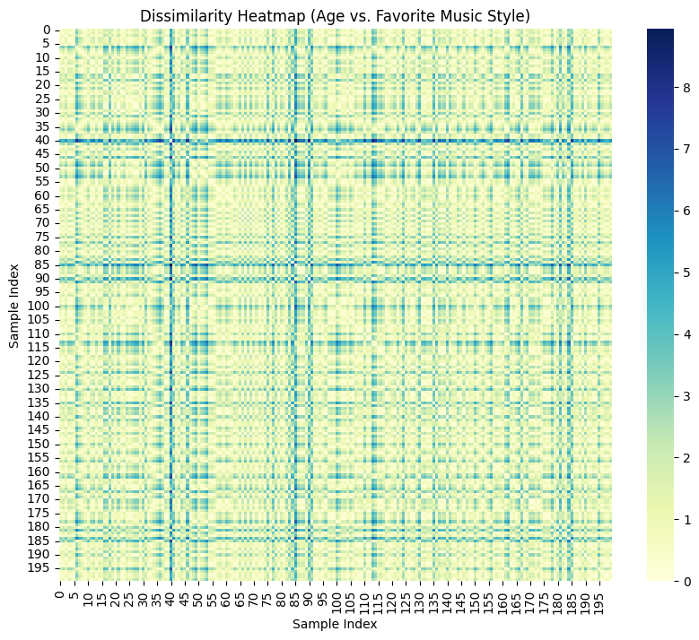

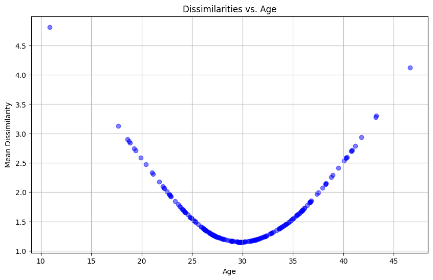

```python
import exercice2.exercice2 as ex2
```

Le but de l'exercice deux était de prendre deux metriques , ici l'age et le style de musique et calculer la dissimilarité moyenne et sa deviation standard.

- On a d'abord généré une heatmap des dissimilarité afin d'avoir une première représentation. On en a pu deduire grace a une analyse des couleurs qu'il existait a la fois des grandes dissimilarités et des petites en fonctions de l'age.
- On as donc decidé de représenter sous une autre vue la heatmap. on a ainsi put observer que la courbe de dissimilarité n'est donc pas plate mais que la dissimilarité varie en fonction de l'âge, l'age de 30 ans etant celui où on retrouve le moins de style de musique différent.

## Exercice 3

```
Logistic Regression Accuracy: 0.8400
SVM Accuracy: 0.8600
Best Model: SVM
Confusion Matrix:
[[260  38]
 [ 19 183]]
Accuracy: 0.886
Precision: 0.8280542986425339
Recall: 0.905940594059406
F1 Score: 0.8652482269503545
```

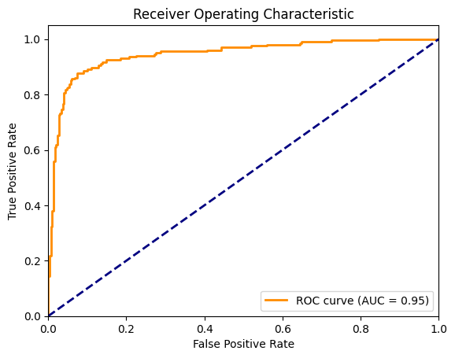

```python
import exercice3.exercice3 as ex3
```

## Exercice 4

```python
import exercice4.exercice4 as ex4
```

```
Ridge R2 Score: 0.5988
Lasso R2 Score: 0.8702
MLPRegressor R2 Score: -0.5653
SVR R2 Score: 0.5487
AdaBoostRegressor R2 Score: 0.3363
Best Model: Lasso
```

Dans cet exercice, nous allons essayer plusieurs méthodes de régression sur l'ensemble de données pour déterminer laquelle est la meilleure, nous donnant le meilleur score R2. Nous allons essayer les méthodes suivantes :

Ridge R2 Score: 0.5988

Lasso R2 Score: 0.8702

SVR R2 Score: 0.5487

Best Model: Lasso

## Exercice 5

Nous allons travailler sur un problème de classification en utilisant un dataset d'Iris. L'objectif est de deviner l'espèce des fleurs d'iris en fonction de leurs dimensions de sépales et de pétales.

Ce dataset contient des mesures de quatre caractéristiques des fleurs d'iris : la longueur des sépales, la largeur des sépales, la longueur des pétales et la largeur des pétales. Il y a trois classes (= espèces) de plantes d'iris dans le dataset : Setosa, Versicolor et Virginica. Chaque classe contient 50 échantillons, pour un total de 150 échantillons dans le dataset.

Download : https://archive.ics.uci.edu/ml/machine-learning-databases/iris/iris.data

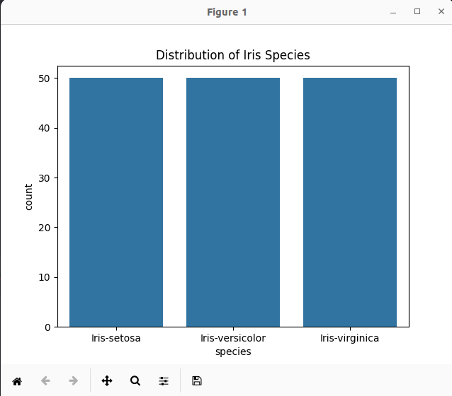

Premièrement, nous pouvons voir que le dataset est équilibré, avec 50 échantillons pour chaque classe.

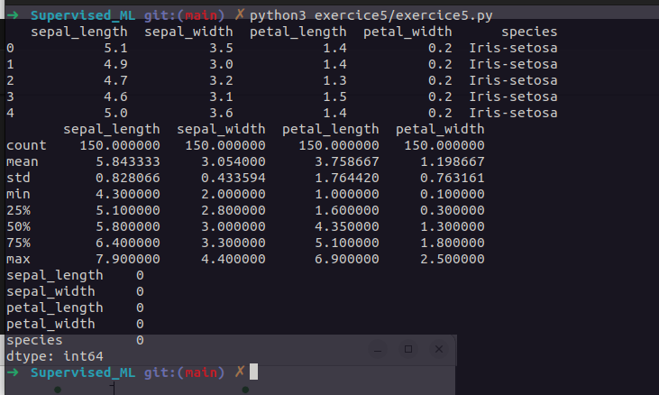

Nous pouvons déjà voir quelques informations sur l'ensemble de données, telles que la moyenne, l'écart type, les valeurs minimales et maximales, et les quartiles.

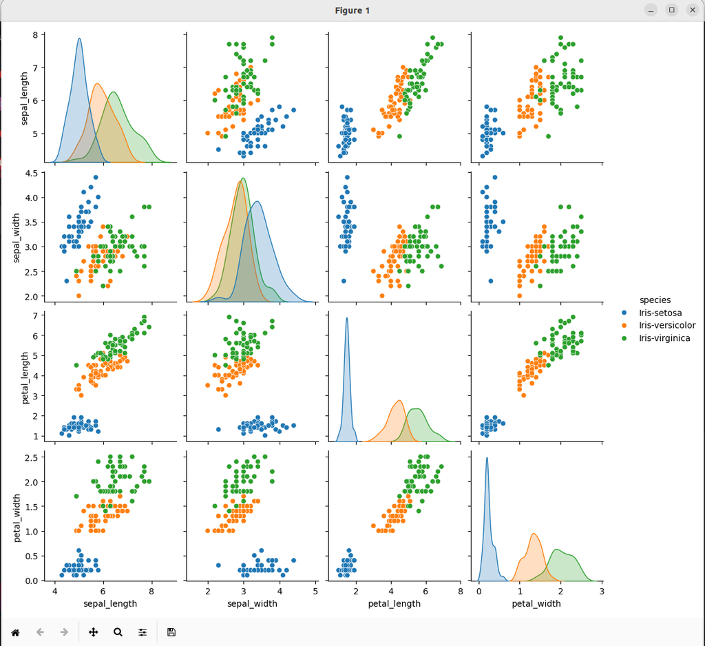